# Income classification on UCI adult dataset with logistic regression

Zhenghang Hu, Cicong Tian

May 18, 2020

# **Introduction**

Hello! And welcome to our first tutorial! In this tutorial, we will analyze data from UCI adult dataset. We will visualize and try to predict whether the income of a person exceeds 50K per year based on some census data. We will use methods and tools that were taught in class in addition to other tools we have researched. To be more specific, We will use logistic regression model to find the relationship between earning a high income and census(age, education, occupation, sex, country, etc.) Generally, cleaning data consumes a lot of time compared with the working with code used for building the model. This project will try to observe the problems occuring while cleaning the data and predicting the accuracy of the models applied on this dataset.

# **Libraries**

For this walkthrough, we are going to be using R. And before we continue, we are going to need to download certain libraries in order to be able to take full advantage of R.

```r
library(readr)
library(dplyr)
library(tidyr)
library(ggplot2)
library(broom)
library(caret)
library(shiny)
library(cowplot)
library(caTools)
library(Amelia)
```

# **Loading/Preparing Data**

### Loading Dataset

The Adult Data Set is downloaded from University of California, Irvine University’s Machine Learning Repository. The data contains anonymous information such as age, occupation, education, working class, etc. The goal is to train a binary classifier to predict the income which has two possible values ‘>50K’ and ‘<50K’. There are 48842 instances and 15 attributes in the dataset. The data contains a good blend of categorical, numerical and missing values.

Listing of key attributes in dataset:

- Age – the age of the person
- Workclass – the type of work the person does (Private, Self-emp-not-inc, Self-emp-inc, Federal-gov, Local-gov, State-gov, Without-pay, Never-worked)
- Education – the highest level of education the person received
- Martial Status – the status of martial (Married-civ-spouse, Divorced, Never-married, Separated, Widowed, Married-spouse-absent, Married-AF-spouse)
- Occupation – the occupation of the person (Tech-support, Craft-repair, Other-service, Sales, Exec-managerial, Prof-specialty, Handlers-cleaners, Machine-op-inspct, Adm- clerical, Farming-fishing, Transport-moving, Priv-house-serv, Protective-serv, Armed-Forces)
- Race – A categorical variable: White, Asian-Pac-Islander, Amer-Indian-Eskimo,Black, other.
- Sex - the sex of the person (male, female)
- Hours per week - Working hours per week
- Native Country - The country that the person is from

Here we load the data locally to be able to manipulate it and use it later. Let’s take a look at a small portion of our data.

```r
adult <- read.csv("adult.csv")
head(adult)
```

```
##   age workclass fnlwgt    education educational.num     marital.status
## 1  25   Private 226802         11th               7      Never-married
## 2  38   Private  89814      HS-grad               9 Married-civ-spouse
## 3  28 Local-gov 336951   Assoc-acdm              12 Married-civ-spouse
## 4  44   Private 160323 Some-college              10 Married-civ-spouse
## 5  18         ? 103497 Some-college              10      Never-married
## 6  34   Private 198693         10th               6      Never-married
##          occupation  relationship  race gender capital.gain capital.loss
## 1 Machine-op-inspct     Own-child Black   Male            0            0
## 2   Farming-fishing       Husband White   Male            0            0
## 3   Protective-serv       Husband White   Male            0            0
## 4 Machine-op-inspct       Husband Black   Male         7688            0
## 5                 ?     Own-child White Female            0            0
## 6     Other-service Not-in-family White   Male            0            0
##   hours.per.week native.country income
## 1             40  United-States  <=50K
## 2             50  United-States  <=50K
## 3             40  United-States   >50K
## 4             40  United-States   >50K
## 5             30  United-States  <=50K
## 6             30  United-States  <=50K
```

Checking the structure of the data.

```r
str(adult)
```

```
## 'data.frame':    48842 obs. of  15 variables:
##  $ age            : int  25 38 28 44 18 34 29 63 24 55 ...
##  $ workclass      : Factor w/ 9 levels "?","Federal-gov",..: 5 5 3 5 1 5 1 7 5 5 ...
##  $ fnlwgt         : int  226802 89814 336951 160323 103497 198693 227026 104626 369667 104996 ...
##  $ education      : Factor w/ 16 levels "10th","11th",..: 2 12 8 16 16 1 12 15 16 6 ...
##  $ educational.num: int  7 9 12 10 10 6 9 15 10 4 ...
##  $ marital.status : Factor w/ 7 levels "Divorced","Married-AF-spouse",..: 5 3 3 3 5 5 5 3 5 3 ...
##  $ occupation     : Factor w/ 15 levels "?","Adm-clerical",..: 8 6 12 8 1 9 1 11 9 4 ...
##  $ relationship   : Factor w/ 6 levels "Husband","Not-in-family",..: 4 1 1 1 4 2 5 1 5 1 ...
##  $ race           : Factor w/ 5 levels "Amer-Indian-Eskimo",..: 3 5 5 3 5 5 3 5 5 5 ...
##  $ gender         : Factor w/ 2 levels "Female","Male": 2 2 2 2 1 2 2 2 1 2 ...
##  $ capital.gain   : int  0 0 0 7688 0 0 0 3103 0 0 ...
##  $ capital.loss   : int  0 0 0 0 0 0 0 0 0 0 ...
##  $ hours.per.week : int  40 50 40 40 30 30 40 32 40 10 ...
##  $ native.country : Factor w/ 42 levels "?","Cambodia",..: 40 40 40 40 40 40 40 40 40 40 ...
##  $ income         : Factor w/ 2 levels "<=50K",">50K": 1 1 2 2 1 1 1 2 1 1 ...
```

Checking the Summary of the data.

```r
summary(adult)
```

```
##       age                   workclass         fnlwgt
##  Min.   :17.00   Private         :33906   Min.   :  12285
##  1st Qu.:28.00   Self-emp-not-inc: 3862   1st Qu.: 117551
##  Median :37.00   Local-gov       : 3136   Median : 178145
##  Mean   :38.64   ?               : 2799   Mean   : 189664
##  3rd Qu.:48.00   State-gov       : 1981   3rd Qu.: 237642
##  Max.   :90.00   Self-emp-inc    : 1695   Max.   :1490400
##                  (Other)         : 1463
##         education     educational.num               marital.status
##  HS-grad     :15784   Min.   : 1.00   Divorced             : 6633
##  Some-college:10878   1st Qu.: 9.00   Married-AF-spouse    :   37
##  Bachelors   : 8025   Median :10.00   Married-civ-spouse   :22379
##  Masters     : 2657   Mean   :10.08   Married-spouse-absent:  628
##  Assoc-voc   : 2061   3rd Qu.:12.00   Never-married        :16117
##  11th        : 1812   Max.   :16.00   Separated            : 1530
##  (Other)     : 7625                   Widowed              : 1518
##            occupation            relationship                   race
##  Prof-specialty : 6172   Husband       :19716   Amer-Indian-Eskimo:  470
##  Craft-repair   : 6112   Not-in-family :12583   Asian-Pac-Islander: 1519
##  Exec-managerial: 6086   Other-relative: 1506   Black             : 4685
##  Adm-clerical   : 5611   Own-child     : 7581   Other             :  406
##  Sales          : 5504   Unmarried     : 5125   White             :41762
##  Other-service  : 4923   Wife          : 2331
##  (Other)        :14434
##     gender       capital.gain    capital.loss    hours.per.week
##  Female:16192   Min.   :    0   Min.   :   0.0   Min.   : 1.00
##  Male  :32650   1st Qu.:    0   1st Qu.:   0.0   1st Qu.:40.00
##                 Median :    0   Median :   0.0   Median :40.00
##                 Mean   : 1079   Mean   :  87.5   Mean   :40.42
##                 3rd Qu.:    0   3rd Qu.:   0.0   3rd Qu.:45.00
##                 Max.   :99999   Max.   :4356.0   Max.   :99.00
##
##        native.country    income
##  United-States:43832   <=50K:37155
##  Mexico       :  951   >50K :11687
##  ?            :  857
##  Philippines  :  295
##  Germany      :  206
##  Puerto-Rico  :  184
##  (Other)      : 2517
```

### Tidying Our Dataset

Now that we have our dataset but we have two problems. One, because our dataset has too much information, it will be impossible to understand in its current stage. We can notice that a lot of columns with cateogrical factors are there, however many of these columns have too many factors than required. In this data cleaning section we’ll try to reduce the number of factors by cleaning the columns. Two, we need to deal with the missing data.

### Workclass column

Using table() for checking the frequency of the workclass column.

```r
table(adult$workclass)
```

```
##
##                ?      Federal-gov        Local-gov     Never-worked
##             2799             1432             3136               10
##          Private     Self-emp-inc Self-emp-not-inc        State-gov
##            33906             1695             3862             1981
##      Without-pay
##               21
```

Null values observed are 2799 and the two smallest groups which we are going to combine are Never-worked and Without-pay. Combining these two smallest groups into a single group called as “Unemployed”.

```r
unemp <- function(job_role){
    job_role <- as.character(job_role)
    if (job_role=="Never-worked" | job_role=="Without-pay"){
        return("Unemployed")
    }else{
        return(job_role)
    }
}
adult$workclass <- sapply(adult$workclass,unemp)
table(adult$workclass)
```

```
##
##                ?      Federal-gov        Local-gov          Private
##             2799             1432             3136            33906
##     Self-emp-inc Self-emp-not-inc        State-gov       Unemployed
##             1695             3862             1981               31
```

We can also combine State and Local gov jobs called “SL-gov” and combine self-employed jobs called “self-emp”.

```r
grp_emp <- function(job_role){
    if (job_role=="Local-gov" | job_role=="State-gov"){
        return("SL-gov")
    }else if (job_role=="Self-emp-inc" | job_role=="Self-emp-not-inc"){
        return("self-emp")
    }else{
        return(job_role)
    }
}
adult$workclass <- sapply(adult$workclass,grp_emp)
table(adult$workclass)
```

```
##
##           ? Federal-gov     Private    self-emp      SL-gov  Unemployed
##        2799        1432       33906        5557        5117          31
```

### Marital Status Column

Using table() for checking the frequency of the martial status column.

```r
table(adult$marital.status)
```

```
##
##              Divorced     Married-AF-spouse    Married-civ-spouse
##                  6633                    37                 22379
## Married-spouse-absent         Never-married             Separated
##                   628                 16117                  1530
##               Widowed
##                  1518
```

We can reduce three groups from this column as: Married Not-Married Never-Married

```r
grp_marital_sts <- function(mart_sts){
    mart_sts <- as.character(mart_sts)

    # Not-Married
    if (mart_sts=="Separated" | mart_sts=="Divorced" | mart_sts=="Widowed"){
        return("Not-Married")

    # Never-Married
    }else if(mart_sts=="Never-married"){
        return(mart_sts)

     #Married
    }else{
        return("Married")
    }
}
adult$marital.status <- sapply(adult$marital.status,grp_marital_sts)
table(adult$marital.status)
```

```
##
##       Married Never-married   Not-Married
##         23044         16117          9681
```

### Country Column

Using table() for checking the frequency of the native country column.

```r
table(adult$native.country)
```

```
##
##                          ?                   Cambodia
##                        857                         28
##                     Canada                      China
##                        182                        122
##                   Columbia                       Cuba
##                         85                        138
##         Dominican-Republic                    Ecuador
##                        103                         45
##                El-Salvador                    England
##                        155                        127
##                     France                    Germany
##                         38                        206
##                     Greece                  Guatemala
##                         49                         88
##                      Haiti         Holand-Netherlands
##                         75                          1
##                   Honduras                       Hong
##                         20                         30
##                    Hungary                      India
##                         19                        151
##                       Iran                    Ireland
##                         59                         37
##                      Italy                    Jamaica
##                        105                        106
##                      Japan                       Laos
##                         92                         23
##                     Mexico                  Nicaragua
##                        951                         49
## Outlying-US(Guam-USVI-etc)                       Peru
##                         23                         46
##                Philippines                     Poland
##                        295                         87
##                   Portugal                Puerto-Rico
##                         67                        184
##                   Scotland                      South
##                         21                        115
##                     Taiwan                   Thailand
##                         65                         30
##            Trinadad&Tobago              United-States
##                         27                      43832
##                    Vietnam                 Yugoslavia
##                         86                         23
```

We will group these countries together into continents. The number of the groups will be reduces significantly.

```r
levels(adult$native.country)
```

```
##  [1] "?"                          "Cambodia"
##  [3] "Canada"                     "China"
##  [5] "Columbia"                   "Cuba"
##  [7] "Dominican-Republic"         "Ecuador"
##  [9] "El-Salvador"                "England"
## [11] "France"                     "Germany"
## [13] "Greece"                     "Guatemala"
## [15] "Haiti"                      "Holand-Netherlands"
## [17] "Honduras"                   "Hong"
## [19] "Hungary"                    "India"
## [21] "Iran"                       "Ireland"
## [23] "Italy"                      "Jamaica"
## [25] "Japan"                      "Laos"
## [27] "Mexico"                     "Nicaragua"
## [29] "Outlying-US(Guam-USVI-etc)" "Peru"
## [31] "Philippines"                "Poland"
## [33] "Portugal"                   "Puerto-Rico"
## [35] "Scotland"                   "South"
## [37] "Taiwan"                     "Thailand"
## [39] "Trinadad&Tobago"            "United-States"
## [41] "Vietnam"                    "Yugoslavia"
```

Using table() for checking the frequency of the native country column.

```r
Asia <- c("China","Hong","India","Iran","Cambodia","Japan", "Laos","Philippines" ,"Vietnam" ,"Taiwan", "Thailand")

N.A <- c("Canada","United-States","Puerto-Rico")

Europe <- c("England","France","Germany" ,"Greece","Holand-Netherlands","Hungary","Ireland","Italy","Poland","Portugal","Scotland"
            ,"Yugoslavia")

S.A <- c("Columbia","Cuba","Dominican-Republic","Ecuador","El-Salvador","Guatemala","Haiti","Honduras","Mexico","Nicaragua"
                   ,"Outlying-US","Peru","Jamaica","Trinadad&Tobago")
Remaining_count <- c("South")

grp_cntry <- function(cntry){
    if (cntry %in% Asia){
        return("Asia")
    }else if (cntry %in% N.A){
        return("N.A")
    }else if (cntry %in% Europe){
        return("Europe")
    }else if (cntry %in% S.A){
        return("S.A")
    }else{
        return("Remaining_count")
    }
}
adult$native.country <- sapply(adult$native.country,grp_cntry)
table(adult$native.country)
```

```
##
##            Asia          Europe             N.A Remaining_count             S.A
##             981             780           44198             995            1888
```

converting data types into factor datatype

```r
adult$workclass <- as.factor(adult$workclass)
adult$native.country <- as.factor(adult$native.country)
adult$marital.status <- as.factor(adult$marital.status)
```

### Missing Data

Converting any value with a ‘?’ or a ’ ?’ value to a NA value.

```r
adult[adult == "?"] <- NA
table(adult$workclass)
```

```
##
##           ? Federal-gov     Private    self-emp      SL-gov  Unemployed
##           0        1432       33906        5557        5117          31
```

```r
adult$workclass <- as.factor(adult$workclass)
adult$native.country <- as.factor(adult$native.country)
adult$marital.status <- as.factor(adult$marital.status)
adult$occupation <- as.factor(adult$occupation)
```

Looking for the missing data using amelia package.

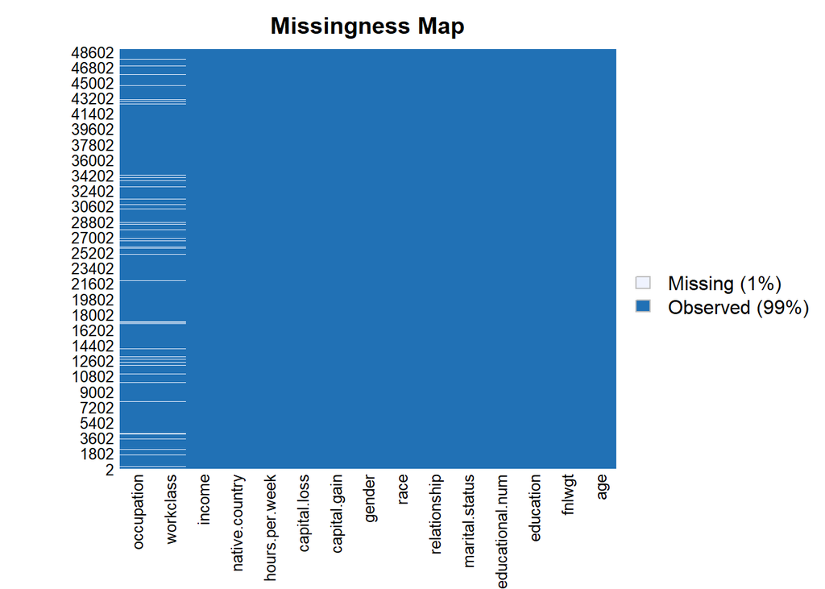

```r
missmap(adult)
```

We can noticed that using missmap(adult), it is a heatmap pointing out missing values (NA). This gives you a quick glance at how much data is missing.

Using na.omit() we can remove NA values from the adult data frame. Note, every single time there is no need to remvove the missing data, it depends on the situation whether it is good or not. You shouldn’t always just drop NA values.

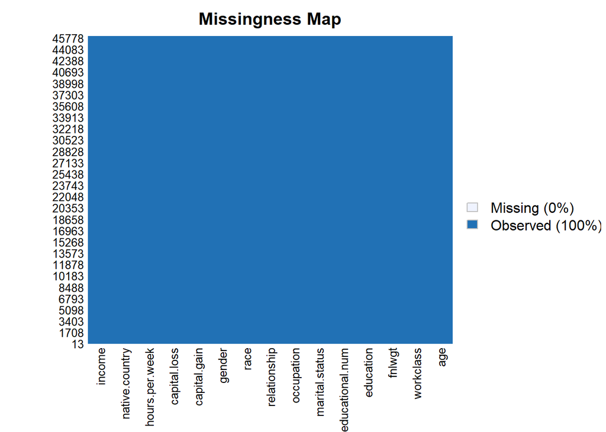

```r
adult <- na.omit(adult)
missmap(adult)
```

# **Exploratory Data Analysis**

### Visualizing Data

At this point, we have cleaned our data. However, at this point the data is still numbers in a table. We need to convert it to visuals in order to truly to see if there is some sort of trend for us to continue. We are going to visualize the data by producing histogram and barplots.

Let’s start by plotting histograms for both age and hours per week attributes. We use ggplot to do the plotting. Documentation can be found at [this website](https://www.rstudio.com/wp-content/uploads/2015/03/ggplot2-cheatsheet.pdf).

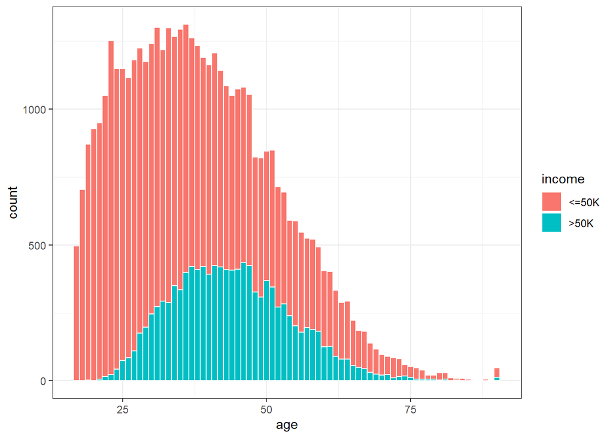

```r
ggplot(adult,aes(age)) + geom_histogram(aes(fill=income),color="white",binwidth=1) + theme_bw()
```

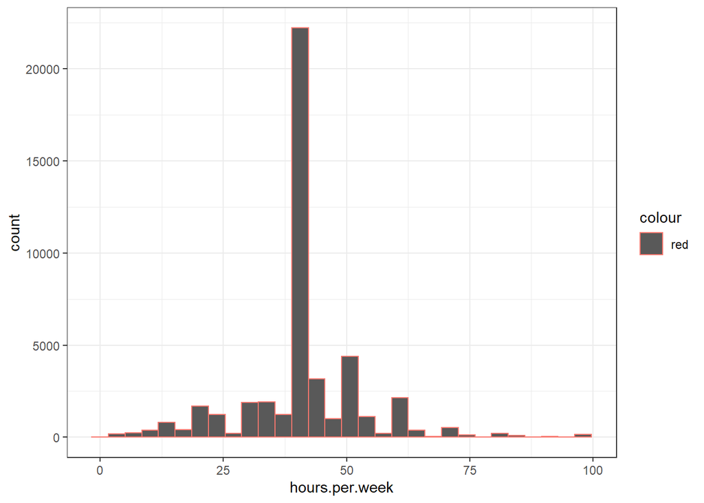

```r
ggplot(adult,aes(hours.per.week)) + geom_histogram(aes(color="red"),bins = 30) + theme_bw()
```

The visualization of these two attributes give us a few interesting insights on the distribution of values.

1. Most of the indivisuals have an age < 50 while the maximum age is around 90. And We did notice people with age more than 50 have less salary income compared to young people.
2. Most of the people work around 40 hrs per week. However there are a few who don’t work and a few who work for almost 100 hours a week.

Now we visualize the produced dataset in a bar graph of country. Bar graph is used to visualize the relationship between a continuous variabel to a categorical attributte.

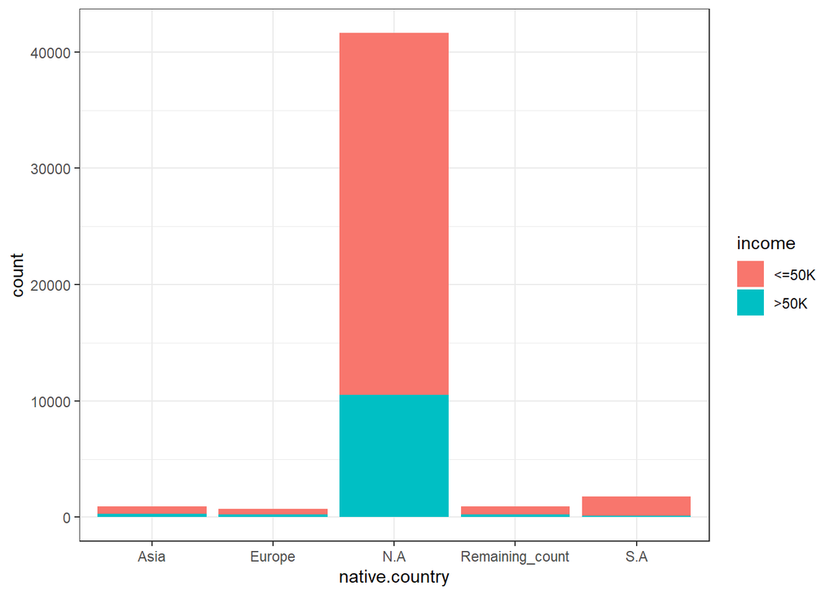

```r
ggplot(adult,aes(native.country)) + geom_bar(aes(fill=income))+theme_bw()
```

From the above plot, we can interpret that the highest number people living in North America earn more than 50k and there are also more number of people earning less than 50k compared with other countries.

# **Predictive Model**

Classification people into two groups: Above or Below 50k in Salary will be done by building a model using logistic regression.

### Preprocessing Data

```r
head(adult)
```

```
##   age workclass fnlwgt    education educational.num marital.status
## 1  25   Private 226802         11th               7  Never-married
## 2  38   Private  89814      HS-grad               9        Married
## 3  28    SL-gov 336951   Assoc-acdm              12        Married
## 4  44   Private 160323 Some-college              10        Married
## 6  34   Private 198693         10th               6  Never-married
## 8  63  self-emp 104626  Prof-school              15        Married
##          occupation  relationship  race gender capital.gain capital.loss
## 1 Machine-op-inspct     Own-child Black   Male            0            0
## 2   Farming-fishing       Husband White   Male            0            0
## 3   Protective-serv       Husband White   Male            0            0
## 4 Machine-op-inspct       Husband Black   Male         7688            0
## 6     Other-service Not-in-family White   Male            0            0
## 8    Prof-specialty       Husband White   Male         3103            0
##   hours.per.week native.country income
## 1             40            N.A  <=50K
## 2             50            N.A  <=50K
## 3             40            N.A   >50K
## 4             40            N.A   >50K
## 6             30            N.A  <=50K
## 8             32            N.A   >50K
```

```r
set.seed(101)
```

Next, we are going to start my partitioning our dataset, so we may use part of it later for testing purposes.

```r
# Split up the sample, basically randomly assigns a booleans to a new column "sample"
sample <- sample.split(adult$income, SplitRatio = 0.70)

# Training Data
train = subset(adult, sample == TRUE)

# Testing Data
test = subset(adult, sample == FALSE)
```

### Creating Logistic Regression Model

Logistic Regression is a type of classification model. In classification models, prediction is done with the categorical dependent variables, using one or more independent variables. The independent variables can be either categorical or numerical. The values of Logistic regression is taken between 0 and 1 based on the logistic function.

```r
model = glm(income ~ ., family = binomial(logit), data = train)
summary(model)
```

```
##
## Call:
## glm(formula = income ~ ., family = binomial(logit), data = train)
##
## Deviance Residuals:
##     Min       1Q   Median       3Q      Max
## -5.2138  -0.5196  -0.1953  -0.0239   3.5470
##
## Coefficients: (1 not defined because of singularities)
##                                 Estimate Std. Error z value Pr(>|z|)
## (Intercept)                   -5.190e+00  3.581e-01 -14.496  < 2e-16 ***
## age                            2.456e-02  1.626e-03  15.102  < 2e-16 ***
## workclassPrivate              -5.264e-01  8.976e-02  -5.864 4.52e-09 ***
## workclassself-emp             -8.551e-01  1.000e-01  -8.547  < 2e-16 ***
## workclassSL-gov               -7.244e-01  1.009e-01  -7.179 7.00e-13 ***
## workclassUnemployed           -1.756e+00  1.076e+00  -1.632 0.102607
## fnlwgt                         8.121e-07  1.688e-07   4.810 1.51e-06 ***
## education11th                  2.261e-01  2.138e-01   1.058 0.290269
## education12th                  6.583e-01  2.667e-01   2.469 0.013564 *
## education1st-4th              -4.800e-01  4.920e-01  -0.975 0.329313
## education5th-6th              -9.676e-02  3.201e-01  -0.302 0.762435
## education7th-8th              -2.669e-01  2.366e-01  -1.128 0.259312
## education9th                  -1.536e-01  2.723e-01  -0.564 0.572582
## educationAssoc-acdm            1.474e+00  1.833e-01   8.044 8.71e-16 ***
## educationAssoc-voc             1.483e+00  1.765e-01   8.401  < 2e-16 ***
## educationBachelors             2.005e+00  1.655e-01  12.114  < 2e-16 ***
## educationDoctorate             2.826e+00  2.201e-01  12.842  < 2e-16 ***
## educationHS-grad               8.735e-01  1.618e-01   5.400 6.68e-08 ***
## educationMasters               2.312e+00  1.746e-01  13.240  < 2e-16 ***
## educationPreschool            -4.313e+00  2.900e+00  -1.487 0.136909
## educationProf-school           2.886e+00  2.080e-01  13.874  < 2e-16 ***
## educationSome-college          1.243e+00  1.638e-01   7.587 3.27e-14 ***
## educational.num                       NA         NA      NA       NA
## marital.statusNever-married   -1.195e+00  1.664e-01  -7.177 7.10e-13 ***
## marital.statusNot-Married     -8.073e-01  1.671e-01  -4.832 1.35e-06 ***
## occupationArmed-Forces        -1.003e+00  1.565e+00  -0.641 0.521403
## occupationCraft-repair        -6.289e-03  7.655e-02  -0.082 0.934515
## occupationExec-managerial      7.468e-01  7.369e-02  10.135  < 2e-16 ***
## occupationFarming-fishing     -1.099e+00  1.360e-01  -8.081 6.44e-16 ***
## occupationHandlers-cleaners   -8.517e-01  1.395e-01  -6.107 1.02e-09 ***
```

[output cut: 20 more lines]

```
## hours.per.week                 2.993e-02  1.619e-03  18.489  < 2e-16 ***
## native.countryEurope           3.578e-01  2.149e-01   1.665 0.095922 .
## native.countryN.A              2.431e-01  1.739e-01   1.398 0.162099
## native.countryRemaining_count -3.044e-01  1.963e-01  -1.550 0.121120
## native.countryS.A             -3.732e-01  2.152e-01  -1.734 0.082864 .
## ---
## Signif. codes:  0 '***' 0.001 '**' 0.01 '*' 0.05 '.' 0.1 ' ' 1
##
## (Dispersion parameter for binomial family taken to be 1)
##
##     Null deviance: 36106  on 32222  degrees of freedom
## Residual deviance: 21023  on 32169  degrees of freedom
## AIC: 21131
##
## Number of Fisher Scoring iterations: 8
```

By analyzing the coefficients of each attributes, we noticed that age, gender and hours per week are statistically significant and have positive effects on the probability that a person exceeds 50K per year.

### Confusion Matrix on tested data

Now we can use the logistic regression model on data reserved for testing and produce the confusion matrix to see how well our model performs.

```r
test$predicted.income = predict(model, newdata=test, type="response")
table(test$income, test$predicted.income > 0.5)
```

```
##
##         FALSE TRUE
##   <=50K  9647  736
##   >50K   1332 2095
```

Based on confusion matrix, we see that 93%( 9647/10383 ) of the people who don’t exceed 50k were classified correctly, however, only 61% ( 2095/3427 ) of the people who exceed 50k were classified correctly. That being said, we have a low false positive rate at the cost of low true positive rate.

Lastly, we can draw a graph that shows the predicted probabilities that each person exceeds 50k along with their actual income status using trained data.

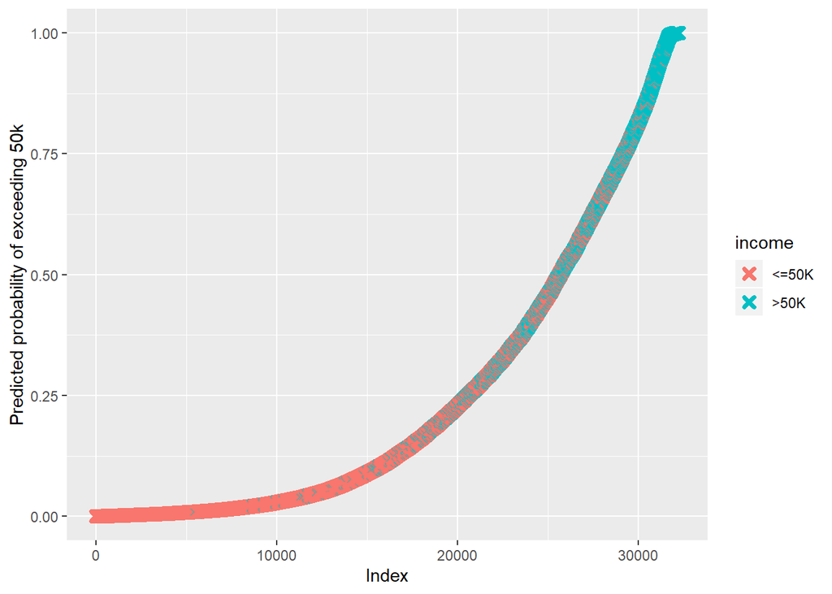

```r
predicted.data <- data.frame(
  probability.of.income = model$fitted.values,
  income = train$income
)

predicted.data <- predicted.data[
  order(predicted.data$probability.of.income, decreasing=FALSE),
]

predicted.data$rank <- 1:nrow(predicted.data)
ggplot(data=predicted.data, aes(x=rank, y=probability.of.income)) +
  geom_point(aes(color=income),alpha=1,shape=4,stroke=2) +
  xlab("Index")+
  ylab("Predicted probability of exceeding 50k")
```

Great! We can now observe that most of the people exceed 50k (the ones in turquoise) are predicted to have a high probability of exceeding 50k, and most of the people don’t exceed 50k (the ones in salmon) are predicted to have low probability of exceeding 50k. Thus, our logistic regression has done a pretty good job.

# **Conclusion**

### Final Thoughts

1. The predictive model we built worked well on trained data but less well on data partitioned for testing. Improvements could be done by using cross-validation, or a different threshold.
2. We used all of the attributes in the dataset to predict income. However, in real life, some attributes may have no influence on the income and got in the way of data analysis.
3. We did notice that we spend more time in data cleaning and removing the missing values than building model.

### Further Resources

If you are interested in further looking at the topic of classifying income using census data, I suggest you take a look at [a similar data analysis done by Python](https://yanhan.github.io/posts/2017-02-15-analysis-of-the-adult-data-set-from-uci-machine-learning-repository.ipynb.html) for a starting place. Also, I also suggest you read [this journal entry](http://robotics.stanford.edu/~ronnyk/nbtree.pdf) because it is suggested by [this website](https://archive.ics.uci.edu/ml/datasets/adult) where I downloaded the audlt dataset. Finally, if you are interested in improving on this model based on better prediction models, I suggest you visit [this tutorial](https://stats.idre.ucla.edu/r/dae/multinomial-logistic-regression/) from UCLA that takes you step-by-step on how to do multi class logistic regression, which is also done in R.

### Citations

- Dobson, A. J. (1990) An Introduction to Generalized Linear Models. London: Chapman and Hall.
- Venables, W. N. and Ripley, B. D. (2002) Modern Applied Statistics with S. New York: Springer (4th ed).